## STA 141A: Assignment 1

# SID:923312684

```r
library(tidyverse)

# Either download the tips dataset from canvas or from the web:

# url <- "https://raw.githubusercontent.com/mwaskom/seaborn-data/master/tips.csv"
# tips <- read_csv(url)
```

## Question 1

We begin with basic data exploration using `tips`.

**(a)** Create a dataframe that contain only five columns that are `total_bill`, `tip`, `sex`, `smoker`, `day`.

```r
#1(a)
library(readr)
tips <- read_csv("tips.csv")
tips_dataframe <- data.frame(
    total_bill = tips$total_bill,
    tip = tips$tip,
    sex = tips$sex,
    smoker = tips$smoker,
    day = tips$day
)
tips_dataframe
```

A data.frame: 244 × 5

| total_bill <dbl> | tip <dbl> | sex <chr> | smoker <chr> | day <chr> |
| --- | --- | --- | --- | --- |
| 16.99 | 1.01 | Female | No | Sun |
| 10.34 | 1.66 | Male | No | Sun |
| 21.01 | 3.50 | Male | No | Sun |
| 23.68 | 3.31 | Male | No | Sun |
| 24.59 | 3.61 | Female | No | Sun |
| 25.29 | 4.71 | Male | No | Sun |
| 8.77 | 2.00 | Male | No | Sun |
| 26.88 | 3.12 | Male | No | Sun |
| 15.04 | 1.96 | Male | No | Sun |
| 14.78 | 3.23 | Male | No | Sun |
| 10.27 | 1.71 | Male | No | Sun |
| 35.26 | 5.00 | Female | No | Sun |
| 15.42 | 1.57 | Male | No | Sun |
| 18.43 | 3.00 | Male | No | Sun |
| 14.83 | 3.02 | Female | No | Sun |
| 21.58 | 3.92 | Male | No | Sun |
| 10.33 | 1.67 | Female | No | Sun |
| 16.29 | 3.71 | Male | No | Sun |
| 16.97 | 3.50 | Female | No | Sun |
| 20.65 | 3.35 | Male | No | Sat |
| 17.92 | 4.08 | Male | No | Sat |
| 20.29 | 2.75 | Female | No | Sat |
| 15.77 | 2.23 | Female | No | Sat |
| 39.42 | 7.58 | Male | No | Sat |
| 19.82 | 3.18 | Male | No | Sat |
| 17.81 | 2.34 | Male | No | Sat |
| 13.37 | 2.00 | Male | No | Sat |
| 12.69 | 2.00 | Male | No | Sat |
| 21.70 | 4.30 | Male | No | Sat |
| 19.65 | 3.00 | Female | No | Sat |
| ⋮ | ⋮ | ⋮ | ⋮ | ⋮ |
| 28.17 | 6.50 | Female | Yes | Sat |
| 12.90 | 1.10 | Female | Yes | Sat |
| 28.15 | 3.00 | Male | Yes | Sat |
| 11.59 | 1.50 | Male | Yes | Sat |
| 7.74 | 1.44 | Male | Yes | Sat |
| 30.14 | 3.09 | Female | Yes | Sat |
| 12.16 | 2.20 | Male | Yes | Fri |
| 13.42 | 3.48 | Female | Yes | Fri |
| 8.58 | 1.92 | Male | Yes | Fri |
| 15.98 | 3.00 | Female | No | Fri |
| 13.42 | 1.58 | Male | Yes | Fri |
| 16.27 | 2.50 | Female | Yes | Fri |
| 10.09 | 2.00 | Female | Yes | Fri |
| 20.45 | 3.00 | Male | No | Sat |
| 13.28 | 2.72 | Male | No | Sat |
| 22.12 | 2.88 | Female | Yes | Sat |
| 24.01 | 2.00 | Male | Yes | Sat |
| 15.69 | 3.00 | Male | Yes | Sat |
| 11.61 | 3.39 | Male | No | Sat |
| 10.77 | 1.47 | Male | No | Sat |
| 15.53 | 3.00 | Male | Yes | Sat |
| 10.07 | 1.25 | Male | No | Sat |
| 12.60 | 1.00 | Male | Yes | Sat |
| 32.83 | 1.17 | Male | Yes | Sat |
| 35.83 | 4.67 | Female | No | Sat |
| 29.03 | 5.92 | Male | No | Sat |
| 27.18 | 2.00 | Female | Yes | Sat |
| 22.67 | 2.00 | Male | Yes | Sat |
| 17.82 | 1.75 | Male | No | Sat |
| 18.78 | 3.00 | Female | No | Thur |

**(b)** Filter the data to include only rows where `total_bill > 20`.

```r
# 1(b)
library(dplyr)
tips_filter <- tips %>%
  filter(total_bill > 20)
tips_filter
```

A spec_tbl_df: 97 × 7

| total_bill <dbl> | tip <dbl> | sex <chr> | smoker <chr> | day <chr> | time <chr> | size <dbl> |
| --- | --- | --- | --- | --- | --- | --- |
| 21.01 | 3.50 | Male | No | Sun | Dinner | 3 |
| 23.68 | 3.31 | Male | No | Sun | Dinner | 2 |
| 24.59 | 3.61 | Female | No | Sun | Dinner | 4 |
| 25.29 | 4.71 | Male | No | Sun | Dinner | 4 |
| 26.88 | 3.12 | Male | No | Sun | Dinner | 4 |
| 35.26 | 5.00 | Female | No | Sun | Dinner | 4 |
| 21.58 | 3.92 | Male | No | Sun | Dinner | 2 |
| 20.65 | 3.35 | Male | No | Sat | Dinner | 3 |
| 20.29 | 2.75 | Female | No | Sat | Dinner | 2 |
| 39.42 | 7.58 | Male | No | Sat | Dinner | 4 |
| 21.70 | 4.30 | Male | No | Sat | Dinner | 2 |
| 20.69 | 2.45 | Female | No | Sat | Dinner | 4 |
| 24.06 | 3.60 | Male | No | Sat | Dinner | 3 |
| 31.27 | 5.00 | Male | No | Sat | Dinner | 3 |
| 30.40 | 5.60 | Male | No | Sun | Dinner | 4 |
| 22.23 | 5.00 | Male | No | Sun | Dinner | 2 |
| 32.40 | 6.00 | Male | No | Sun | Dinner | 4 |
| 28.55 | 2.05 | Male | No | Sun | Dinner | 3 |
| 34.81 | 5.20 | Female | No | Sun | Dinner | 4 |
| 25.56 | 4.34 | Male | No | Sun | Dinner | 4 |
| 38.01 | 3.00 | Male | Yes | Sat | Dinner | 4 |
| 26.41 | 1.50 | Female | No | Sat | Dinner | 2 |
| 48.27 | 6.73 | Male | No | Sat | Dinner | 4 |
| 20.29 | 3.21 | Male | Yes | Sat | Dinner | 2 |
| 20.08 | 3.15 | Male | No | Sat | Dinner | 3 |
| 20.23 | 2.01 | Male | No | Sat | Dinner | 2 |
| 26.86 | 3.14 | Female | Yes | Sat | Dinner | 2 |
| 25.28 | 5.00 | Female | Yes | Sat | Dinner | 2 |
| 27.20 | 4.00 | Male | No | Thur | Lunch | 4 |
| 22.76 | 3.00 | Male | No | Thur | Lunch | 2 |
| ⋮ | ⋮ | ⋮ | ⋮ | ⋮ | ⋮ | ⋮ |
| 34.63 | 3.55 | Male | Yes | Sun | Dinner | 2 |
| 34.65 | 3.68 | Male | Yes | Sun | Dinner | 4 |
| 23.33 | 5.65 | Male | Yes | Sun | Dinner | 2 |
| 45.35 | 3.50 | Male | Yes | Sun | Dinner | 3 |
| 23.17 | 6.50 | Male | Yes | Sun | Dinner | 4 |
| 40.55 | 3.00 | Male | Yes | Sun | Dinner | 2 |
| 20.69 | 5.00 | Male | No | Sun | Dinner | 5 |
| 20.90 | 3.50 | Female | Yes | Sun | Dinner | 3 |
| 30.46 | 2.00 | Male | Yes | Sun | Dinner | 5 |
| 23.10 | 4.00 | Male | Yes | Sun | Dinner | 3 |
| 28.44 | 2.56 | Male | Yes | Thur | Lunch | 2 |
| 43.11 | 5.00 | Female | Yes | Thur | Lunch | 4 |
| 20.53 | 4.00 | Male | Yes | Thur | Lunch | 4 |
| 26.59 | 3.41 | Male | Yes | Sat | Dinner | 3 |
| 38.73 | 3.00 | Male | Yes | Sat | Dinner | 4 |
| 24.27 | 2.03 | Male | Yes | Sat | Dinner | 2 |
| 30.06 | 2.00 | Male | Yes | Sat | Dinner | 3 |
| 25.89 | 5.16 | Male | Yes | Sat | Dinner | 4 |
| 48.33 | 9.00 | Male | No | Sat | Dinner | 4 |
| 28.17 | 6.50 | Female | Yes | Sat | Dinner | 3 |
| 28.15 | 3.00 | Male | Yes | Sat | Dinner | 5 |
| 30.14 | 3.09 | Female | Yes | Sat | Dinner | 4 |
| 20.45 | 3.00 | Male | No | Sat | Dinner | 4 |
| 22.12 | 2.88 | Female | Yes | Sat | Dinner | 2 |
| 24.01 | 2.00 | Male | Yes | Sat | Dinner | 4 |
| 32.83 | 1.17 | Male | Yes | Sat | Dinner | 2 |
| 35.83 | 4.67 | Female | No | Sat | Dinner | 3 |
| 29.03 | 5.92 | Male | No | Sat | Dinner | 3 |
| 27.18 | 2.00 | Female | Yes | Sat | Dinner | 2 |
| 22.67 | 2.00 | Male | Yes | Sat | Dinner | 2 |

**(c)** Arrange the filtered data from (b) in *descending* order of `tip`.

```r
# 1(c)
tips_decease <- tips_filter %>% arrange(desc(tip))
tips_decease
```

A spec_tbl_df: 97 × 7

| total_bill <dbl> | tip <dbl> | sex <chr> | smoker <chr> | day <chr> | time <chr> | size <dbl> |
| --- | --- | --- | --- | --- | --- | --- |
| 50.81 | 10.00 | Male | Yes | Sat | Dinner | 3 |
| 48.33 | 9.00 | Male | No | Sat | Dinner | 4 |
| 39.42 | 7.58 | Male | No | Sat | Dinner | 4 |
| 48.27 | 6.73 | Male | No | Sat | Dinner | 4 |
| 34.30 | 6.70 | Male | No | Thur | Lunch | 6 |
| 23.17 | 6.50 | Male | Yes | Sun | Dinner | 4 |
| 28.17 | 6.50 | Female | Yes | Sat | Dinner | 3 |
| 32.40 | 6.00 | Male | No | Sun | Dinner | 4 |
| 29.03 | 5.92 | Male | No | Sat | Dinner | 3 |
| 24.71 | 5.85 | Male | No | Thur | Lunch | 2 |
| 23.33 | 5.65 | Male | Yes | Sun | Dinner | 2 |
| 30.40 | 5.60 | Male | No | Sun | Dinner | 4 |
| 34.81 | 5.20 | Female | No | Sun | Dinner | 4 |
| 34.83 | 5.17 | Female | No | Thur | Lunch | 4 |
| 25.89 | 5.16 | Male | Yes | Sat | Dinner | 4 |
| 29.85 | 5.14 | Female | No | Sun | Dinner | 5 |
| 29.93 | 5.07 | Male | No | Sun | Dinner | 4 |
| 35.26 | 5.00 | Female | No | Sun | Dinner | 4 |
| 31.27 | 5.00 | Male | No | Sat | Dinner | 3 |
| 22.23 | 5.00 | Male | No | Sun | Dinner | 2 |
| 25.28 | 5.00 | Female | Yes | Sat | Dinner | 2 |
| 32.68 | 5.00 | Male | Yes | Thur | Lunch | 2 |
| 41.19 | 5.00 | Male | No | Thur | Lunch | 5 |
| 27.05 | 5.00 | Female | No | Thur | Lunch | 6 |
| 48.17 | 5.00 | Male | No | Sun | Dinner | 6 |
| 20.69 | 5.00 | Male | No | Sun | Dinner | 5 |
| 43.11 | 5.00 | Female | Yes | Thur | Lunch | 4 |
| 40.17 | 4.73 | Male | Yes | Fri | Dinner | 4 |
| 25.29 | 4.71 | Male | No | Sun | Dinner | 4 |
| 35.83 | 4.67 | Female | No | Sat | Dinner | 3 |
| ⋮ | ⋮ | ⋮ | ⋮ | ⋮ | ⋮ | ⋮ |
| 38.01 | 3.00 | Male | Yes | Sat | Dinner | 4 |
| 22.76 | 3.00 | Male | No | Thur | Lunch | 2 |
| 21.16 | 3.00 | Male | No | Thur | Lunch | 2 |
| 28.97 | 3.00 | Male | Yes | Fri | Dinner | 2 |
| 21.01 | 3.00 | Male | Yes | Fri | Dinner | 2 |
| 40.55 | 3.00 | Male | Yes | Sun | Dinner | 2 |
| 38.73 | 3.00 | Male | Yes | Sat | Dinner | 4 |
| 28.15 | 3.00 | Male | Yes | Sat | Dinner | 5 |
| 20.45 | 3.00 | Male | No | Sat | Dinner | 4 |
| 24.08 | 2.92 | Female | No | Thur | Lunch | 4 |
| 22.12 | 2.88 | Female | Yes | Sat | Dinner | 2 |
| 20.27 | 2.83 | Female | No | Thur | Lunch | 2 |
| 20.29 | 2.75 | Female | No | Sat | Dinner | 2 |
| 28.44 | 2.56 | Male | Yes | Thur | Lunch | 2 |
| 23.95 | 2.55 | Male | No | Sun | Dinner | 2 |
| 44.30 | 2.50 | Female | Yes | Sat | Dinner | 3 |
| 20.69 | 2.45 | Female | No | Sat | Dinner | 4 |
| 20.76 | 2.24 | Male | No | Sun | Dinner | 2 |
| 22.82 | 2.18 | Male | No | Thur | Lunch | 3 |
| 28.55 | 2.05 | Male | No | Sun | Dinner | 3 |
| 24.27 | 2.03 | Male | Yes | Sat | Dinner | 2 |
| 20.23 | 2.01 | Male | No | Sat | Dinner | 2 |
| 24.55 | 2.00 | Male | No | Sun | Dinner | 4 |
| 30.46 | 2.00 | Male | Yes | Sun | Dinner | 5 |
| 30.06 | 2.00 | Male | Yes | Sat | Dinner | 3 |
| 24.01 | 2.00 | Male | Yes | Sat | Dinner | 4 |
| 27.18 | 2.00 | Female | Yes | Sat | Dinner | 2 |
| 22.67 | 2.00 | Male | Yes | Sat | Dinner | 2 |
| 26.41 | 1.50 | Female | No | Sat | Dinner | 2 |
| 32.83 | 1.17 | Male | Yes | Sat | Dinner | 2 |

**(d)** What is the mean tip among bills greater than $20?

```r
# 1(d)
tip_means <- mean(tips_filter$tip)
tip_means
```

3.92948453608247

The mean tips among bills greater than $20 is 3.9294

## Question 2

**(a)** Create a new variable `tip_pct = tip / total_bill`.

```r
# 2(a)
tips2 <- tips |>
  mutate(tip_pct = tip / total_bill)

tips2
```

A tibble: 244 × 8

| total_bill <dbl> | tip <dbl> | sex <chr> | smoker <chr> | day <chr> | time <chr> | size <dbl> | tip_pct <dbl> |
| --- | --- | --- | --- | --- | --- | --- | --- |
| 16.99 | 1.01 | Female | No | Sun | Dinner | 2 | 0.05944673 |
| 10.34 | 1.66 | Male | No | Sun | Dinner | 3 | 0.16054159 |
| 21.01 | 3.50 | Male | No | Sun | Dinner | 3 | 0.16658734 |
| 23.68 | 3.31 | Male | No | Sun | Dinner | 2 | 0.13978041 |
| 24.59 | 3.61 | Female | No | Sun | Dinner | 4 | 0.14680765 |
| 25.29 | 4.71 | Male | No | Sun | Dinner | 4 | 0.18623962 |
| 8.77 | 2.00 | Male | No | Sun | Dinner | 2 | 0.22805017 |
| 26.88 | 3.12 | Male | No | Sun | Dinner | 4 | 0.11607143 |
| 15.04 | 1.96 | Male | No | Sun | Dinner | 2 | 0.13031915 |
| 14.78 | 3.23 | Male | No | Sun | Dinner | 2 | 0.21853857 |
| 10.27 | 1.71 | Male | No | Sun | Dinner | 2 | 0.16650438 |
| 35.26 | 5.00 | Female | No | Sun | Dinner | 4 | 0.14180374 |
| 15.42 | 1.57 | Male | No | Sun | Dinner | 2 | 0.10181582 |
| 18.43 | 3.00 | Male | No | Sun | Dinner | 4 | 0.16277808 |
| 14.83 | 3.02 | Female | No | Sun | Dinner | 2 | 0.20364127 |
| 21.58 | 3.92 | Male | No | Sun | Dinner | 2 | 0.18164968 |
| 10.33 | 1.67 | Female | No | Sun | Dinner | 3 | 0.16166505 |
| 16.29 | 3.71 | Male | No | Sun | Dinner | 3 | 0.22774708 |
| 16.97 | 3.50 | Female | No | Sun | Dinner | 3 | 0.20624632 |
| 20.65 | 3.35 | Male | No | Sat | Dinner | 3 | 0.16222760 |
| 17.92 | 4.08 | Male | No | Sat | Dinner | 2 | 0.22767857 |
| 20.29 | 2.75 | Female | No | Sat | Dinner | 2 | 0.13553475 |
| 15.77 | 2.23 | Female | No | Sat | Dinner | 2 | 0.14140774 |
| 39.42 | 7.58 | Male | No | Sat | Dinner | 4 | 0.19228818 |
| 19.82 | 3.18 | Male | No | Sat | Dinner | 2 | 0.16044400 |
| 17.81 | 2.34 | Male | No | Sat | Dinner | 4 | 0.13138686 |
| 13.37 | 2.00 | Male | No | Sat | Dinner | 2 | 0.14958863 |
| 12.69 | 2.00 | Male | No | Sat | Dinner | 2 | 0.15760441 |
| 21.70 | 4.30 | Male | No | Sat | Dinner | 2 | 0.19815668 |
| 19.65 | 3.00 | Female | No | Sat | Dinner | 2 | 0.15267176 |
| ⋮ | ⋮ | ⋮ | ⋮ | ⋮ | ⋮ | ⋮ | ⋮ |
| 28.17 | 6.50 | Female | Yes | Sat | Dinner | 3 | 0.23074192 |
| 12.90 | 1.10 | Female | Yes | Sat | Dinner | 2 | 0.08527132 |
| 28.15 | 3.00 | Male | Yes | Sat | Dinner | 5 | 0.10657194 |
| 11.59 | 1.50 | Male | Yes | Sat | Dinner | 2 | 0.12942192 |
| 7.74 | 1.44 | Male | Yes | Sat | Dinner | 2 | 0.18604651 |
| 30.14 | 3.09 | Female | Yes | Sat | Dinner | 4 | 0.10252157 |
| 12.16 | 2.20 | Male | Yes | Fri | Lunch | 2 | 0.18092105 |
| 13.42 | 3.48 | Female | Yes | Fri | Lunch | 2 | 0.25931446 |
| 8.58 | 1.92 | Male | Yes | Fri | Lunch | 1 | 0.22377622 |
| 15.98 | 3.00 | Female | No | Fri | Lunch | 3 | 0.18773467 |
| 13.42 | 1.58 | Male | Yes | Fri | Lunch | 2 | 0.11773472 |
| 16.27 | 2.50 | Female | Yes | Fri | Lunch | 2 | 0.15365704 |
| 10.09 | 2.00 | Female | Yes | Fri | Lunch | 2 | 0.19821606 |
| 20.45 | 3.00 | Male | No | Sat | Dinner | 4 | 0.14669927 |
| 13.28 | 2.72 | Male | No | Sat | Dinner | 2 | 0.20481928 |
| 22.12 | 2.88 | Female | Yes | Sat | Dinner | 2 | 0.13019892 |
| 24.01 | 2.00 | Male | Yes | Sat | Dinner | 4 | 0.08329863 |
| 15.69 | 3.00 | Male | Yes | Sat | Dinner | 3 | 0.19120459 |
| 11.61 | 3.39 | Male | No | Sat | Dinner | 2 | 0.29198966 |
| 10.77 | 1.47 | Male | No | Sat | Dinner | 2 | 0.13649025 |
| 15.53 | 3.00 | Male | Yes | Sat | Dinner | 2 | 0.19317450 |
| 10.07 | 1.25 | Male | No | Sat | Dinner | 2 | 0.12413108 |
| 12.60 | 1.00 | Male | Yes | Sat | Dinner | 2 | 0.07936508 |
| 32.83 | 1.17 | Male | Yes | Sat | Dinner | 2 | 0.03563814 |
| 35.83 | 4.67 | Female | No | Sat | Dinner | 3 | 0.13033771 |
| 29.03 | 5.92 | Male | No | Sat | Dinner | 3 | 0.20392697 |
| 27.18 | 2.00 | Female | Yes | Sat | Dinner | 2 | 0.07358352 |
| 22.67 | 2.00 | Male | Yes | Sat | Dinner | 2 | 0.08822232 |
| 17.82 | 1.75 | Male | No | Sat | Dinner | 2 | 0.09820426 |
| 18.78 | 3.00 | Female | No | Thur | Dinner | 2 | 0.15974441 |

**(b)** Create a variable `large_party` that is `TRUE` if the party size (`size`) is at least 4.

```r
# 2(b)
tips_2  <- tips2 |>
  mutate(large_party = if_else(size >= 4, TRUE, FALSE))

tips_2
```

A tibble: 244 × 9

| total_bill <dbl> | tip <dbl> | sex <chr> | smoker <chr> | day <chr> | time <chr> | size <dbl> | tip_pct <dbl> | large_party <lgl> |
| --- | --- | --- | --- | --- | --- | --- | --- | --- |
| 16.99 | 1.01 | Female | No | Sun | Dinner | 2 | 0.05944673 | FALSE |
| 10.34 | 1.66 | Male | No | Sun | Dinner | 3 | 0.16054159 | FALSE |
| 21.01 | 3.50 | Male | No | Sun | Dinner | 3 | 0.16658734 | FALSE |
| 23.68 | 3.31 | Male | No | Sun | Dinner | 2 | 0.13978041 | FALSE |
| 24.59 | 3.61 | Female | No | Sun | Dinner | 4 | 0.14680765 | TRUE |
| 25.29 | 4.71 | Male | No | Sun | Dinner | 4 | 0.18623962 | TRUE |
| 8.77 | 2.00 | Male | No | Sun | Dinner | 2 | 0.22805017 | FALSE |
| 26.88 | 3.12 | Male | No | Sun | Dinner | 4 | 0.11607143 | TRUE |
| 15.04 | 1.96 | Male | No | Sun | Dinner | 2 | 0.13031915 | FALSE |
| 14.78 | 3.23 | Male | No | Sun | Dinner | 2 | 0.21853857 | FALSE |
| 10.27 | 1.71 | Male | No | Sun | Dinner | 2 | 0.16650438 | FALSE |
| 35.26 | 5.00 | Female | No | Sun | Dinner | 4 | 0.14180374 | TRUE |
| 15.42 | 1.57 | Male | No | Sun | Dinner | 2 | 0.10181582 | FALSE |
| 18.43 | 3.00 | Male | No | Sun | Dinner | 4 | 0.16277808 | TRUE |
| 14.83 | 3.02 | Female | No | Sun | Dinner | 2 | 0.20364127 | FALSE |
| 21.58 | 3.92 | Male | No | Sun | Dinner | 2 | 0.18164968 | FALSE |
| 10.33 | 1.67 | Female | No | Sun | Dinner | 3 | 0.16166505 | FALSE |
| 16.29 | 3.71 | Male | No | Sun | Dinner | 3 | 0.22774708 | FALSE |
| 16.97 | 3.50 | Female | No | Sun | Dinner | 3 | 0.20624632 | FALSE |
| 20.65 | 3.35 | Male | No | Sat | Dinner | 3 | 0.16222760 | FALSE |
| 17.92 | 4.08 | Male | No | Sat | Dinner | 2 | 0.22767857 | FALSE |
| 20.29 | 2.75 | Female | No | Sat | Dinner | 2 | 0.13553475 | FALSE |
| 15.77 | 2.23 | Female | No | Sat | Dinner | 2 | 0.14140774 | FALSE |
| 39.42 | 7.58 | Male | No | Sat | Dinner | 4 | 0.19228818 | TRUE |
| 19.82 | 3.18 | Male | No | Sat | Dinner | 2 | 0.16044400 | FALSE |
| 17.81 | 2.34 | Male | No | Sat | Dinner | 4 | 0.13138686 | TRUE |
| 13.37 | 2.00 | Male | No | Sat | Dinner | 2 | 0.14958863 | FALSE |
| 12.69 | 2.00 | Male | No | Sat | Dinner | 2 | 0.15760441 | FALSE |
| 21.70 | 4.30 | Male | No | Sat | Dinner | 2 | 0.19815668 | FALSE |
| 19.65 | 3.00 | Female | No | Sat | Dinner | 2 | 0.15267176 | FALSE |
| ⋮ | ⋮ | ⋮ | ⋮ | ⋮ | ⋮ | ⋮ | ⋮ | ⋮ |
| 28.17 | 6.50 | Female | Yes | Sat | Dinner | 3 | 0.23074192 | FALSE |
| 12.90 | 1.10 | Female | Yes | Sat | Dinner | 2 | 0.08527132 | FALSE |
| 28.15 | 3.00 | Male | Yes | Sat | Dinner | 5 | 0.10657194 | TRUE |
| 11.59 | 1.50 | Male | Yes | Sat | Dinner | 2 | 0.12942192 | FALSE |
| 7.74 | 1.44 | Male | Yes | Sat | Dinner | 2 | 0.18604651 | FALSE |
| 30.14 | 3.09 | Female | Yes | Sat | Dinner | 4 | 0.10252157 | TRUE |
| 12.16 | 2.20 | Male | Yes | Fri | Lunch | 2 | 0.18092105 | FALSE |
| 13.42 | 3.48 | Female | Yes | Fri | Lunch | 2 | 0.25931446 | FALSE |
| 8.58 | 1.92 | Male | Yes | Fri | Lunch | 1 | 0.22377622 | FALSE |
| 15.98 | 3.00 | Female | No | Fri | Lunch | 3 | 0.18773467 | FALSE |
| 13.42 | 1.58 | Male | Yes | Fri | Lunch | 2 | 0.11773472 | FALSE |
| 16.27 | 2.50 | Female | Yes | Fri | Lunch | 2 | 0.15365704 | FALSE |
| 10.09 | 2.00 | Female | Yes | Fri | Lunch | 2 | 0.19821606 | FALSE |
| 20.45 | 3.00 | Male | No | Sat | Dinner | 4 | 0.14669927 | TRUE |
| 13.28 | 2.72 | Male | No | Sat | Dinner | 2 | 0.20481928 | FALSE |
| 22.12 | 2.88 | Female | Yes | Sat | Dinner | 2 | 0.13019892 | FALSE |
| 24.01 | 2.00 | Male | Yes | Sat | Dinner | 4 | 0.08329863 | TRUE |
| 15.69 | 3.00 | Male | Yes | Sat | Dinner | 3 | 0.19120459 | FALSE |
| 11.61 | 3.39 | Male | No | Sat | Dinner | 2 | 0.29198966 | FALSE |
| 10.77 | 1.47 | Male | No | Sat | Dinner | 2 | 0.13649025 | FALSE |
| 15.53 | 3.00 | Male | Yes | Sat | Dinner | 2 | 0.19317450 | FALSE |
| 10.07 | 1.25 | Male | No | Sat | Dinner | 2 | 0.12413108 | FALSE |
| 12.60 | 1.00 | Male | Yes | Sat | Dinner | 2 | 0.07936508 | FALSE |
| 32.83 | 1.17 | Male | Yes | Sat | Dinner | 2 | 0.03563814 | FALSE |
| 35.83 | 4.67 | Female | No | Sat | Dinner | 3 | 0.13033771 | FALSE |
| 29.03 | 5.92 | Male | No | Sat | Dinner | 3 | 0.20392697 | FALSE |
| 27.18 | 2.00 | Female | Yes | Sat | Dinner | 2 | 0.07358352 | FALSE |
| 22.67 | 2.00 | Male | Yes | Sat | Dinner | 2 | 0.08822232 | FALSE |
| 17.82 | 1.75 | Male | No | Sat | Dinner | 2 | 0.09820426 | FALSE |
| 18.78 | 3.00 | Female | No | Thur | Dinner | 2 | 0.15974441 | FALSE |

**(c)** Compute the mean tip percentage for *large parties* and *small parties* separately. Hint:use `group_by()` and `summarise()`.

```r
# 2(c)
tip_group <- tips_2 |>
  group_by(large_party) |>
  summarise(
    mean_tip_pct = mean(tip_pct,na.rm = TRUE),
    n = n()
  )

tip_group
```

A tibble: 2 × 3

| large_party <lgl> | mean_tip_pct <dbl> | n <int> |
| --- | --- | --- |
| FALSE | 0.1641582 | 198 |
| TRUE | 0.1463589 | 46 |

**(d)** Make a simple scatterplot of `total_bill` versus `tip_pct`.

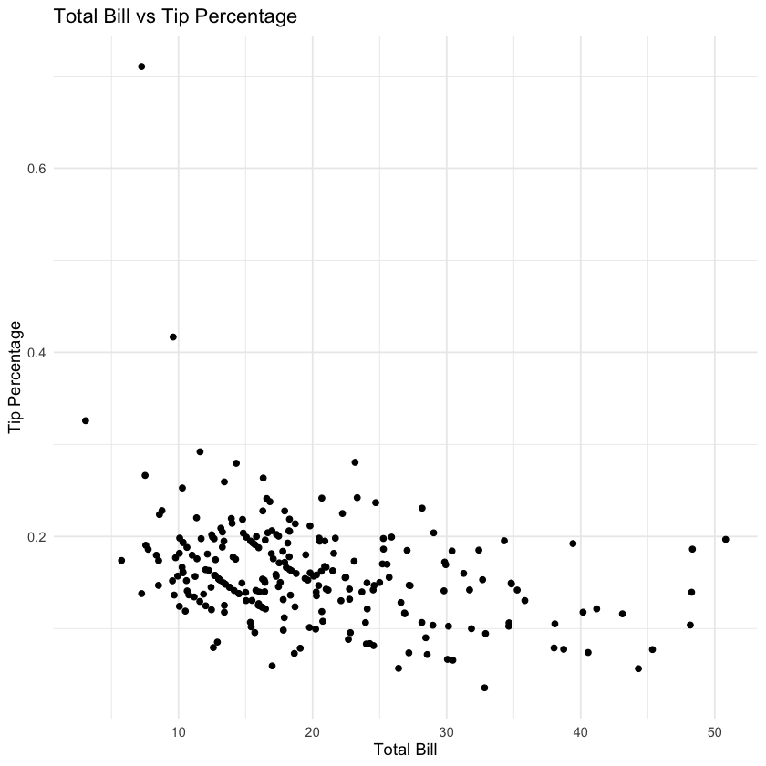

```r
# 2(d)
library(ggplot2)
tips_2 |>
  ggplot(aes(x = total_bill, y = tip_pct)) +
  geom_point() +
  theme_minimal() +
  labs(
    title = "Total Bill vs Tip Percentage",
    x = "Total Bill",
    y = "Tip Percentage"
  )
```

## Question 3

**(a)** For each `day`, compute (i) mean `total_bill`, (ii) mean `tip`, and (iii) number of observations (`n()`).

```r
# 3(a)
tips <- read.csv("tips.csv")

tips_day <- tips |>
  group_by(day) |>
  summarise(
    mean_total_bill = mean(total_bill,na.rm = TRUE),
    mean_tip = mean(tip,na.rm = TRUE),
    n = n()
  )

tips_day
```

A tibble: 4 × 4

| day <chr> | mean_total_bill <dbl> | mean_tip <dbl> | n <int> |
| --- | --- | --- | --- |
| Fri | 17.15158 | 2.734737 | 19 |
| Sat | 20.44138 | 2.993103 | 87 |
| Sun | 21.41000 | 3.255132 | 76 |
| Thur | 17.68274 | 2.771452 | 62 |

**(b)** Which day has the highest mean tip percentage? (You will need to compute `tip_pct` first.)

```r
# 3(b)
tips <- read.csv("tips.csv")

tips_pct <- tips |>
  group_by(day) |>
  summarise(
    tip_pct = mean(tip / total_bill, na.rm = TRUE),
    n = n()
  )

tips_pct
```

A tibble: 4 × 3

| day <chr> | tip_pct <dbl> | n <int> |
| --- | --- | --- |
| Fri | 0.1699130 | 19 |
| Sat | 0.1531517 | 87 |
| Sun | 0.1668973 | 76 |
| Thur | 0.1612756 | 62 |

In the table, you can check that Friday has the highest mean tip percentage

## Question 4

Consider the following tables.

```r
customers <- tibble(
  id = c(1, 2, 3, 4),
  name = c("Alice", "Bob", "Carol", "David")
)

orders <- tibble(
  order_id = c(100, 101, 102, 103, 104),
  customer_id = c(1, 3, 4, 4, 5),
  total = c(25, 40, 13, 19, 50)
)
```

**(a)** Perform a *left join* of `customers` and `orders`. Explain what happens to customer 2.

```r
# 4(a)
customers |>
  left_join(orders, by = c("id" = "customer_id"))
```

A tibble: 5 × 4

| id <dbl> | name <chr> | order_id <dbl> | total <dbl> |
| --- | --- | --- | --- |
| 1 | Alice | 100 | 25 |
| 2 | Bob | NA | NA |
| 3 | Carol | 101 | 40 |
| 4 | David | 102 | 13 |
| 4 | David | 103 | 19 |

The customer2 is Bob, but in the order there is no record for him. So that means Bob did not purchase anything.

**(b)** Perform an *inner join* of the same tables. Explain what happens to customer 2 and customer 5.

```r
# 4(b)
customers |>
  inner_join(orders, by = c("id" = "customer_id"))
```

A tibble: 4 × 4

| id <dbl> | name <chr> | order_id <dbl> | total <dbl> |
| --- | --- | --- | --- |
| 1 | Alice | 100 | 25 |
| 3 | Carol | 101 | 40 |
| 4 | David | 102 | 13 |
| 4 | David | 103 | 19 |

The inner join is make sure it both has records in orders and customers. And in the customers there is no number 5 customer, and as the last question I mentioned that customer 2 did not purchase anything. So this is why customer 2 and customer 5 both missing in the table.

**(c)** Compute the *average order total* (mean `total`) by customer name

```r
# 4(c)
customers |>
  inner_join(orders, by = c("id" = "customer_id")) |>
    group_by(name) |>
    summarise(
      total_mean = mean(total, na.rm = TRUE)
    )
```

A tibble: 3 × 2

| name <chr> | total_mean <dbl> |
| --- | --- |
| Alice | 25 |
| Carol | 40 |
| David | 16 |

## Question 5

Consider another dataset as follows.

```r
scores <- tibble(
  id = c(1,1,2,2,3,3),
  subject = c("math","stats","math","stats","math","stats"),
  score = c(90,85,70,88,95,80)
)

info <- tibble(
  id = c(1,2,3),
  major = c("Stat","Econ","CS")
)
```

**(a)** Join the two tables by `id`.

```r
# 5(a)
scores |>
  left_join(info, by = "id")
```

A tibble: 6 × 4

| id <dbl> | subject <chr> | score <dbl> | major <chr> |
| --- | --- | --- | --- |
| 1 | math | 90 | Stat |
| 1 | stats | 85 | Stat |
| 2 | math | 70 | Econ |
| 2 | stats | 88 | Econ |
| 3 | math | 95 | CS |
| 3 | stats | 80 | CS |

**(b)** Compute the *mean score* for each combination of (`major`, `subject`).

```r
# 5(b)
mean_scores <- scores |>
  left_join(info, by = "id")|>
    group_by(major,subject) |>
    summarise(
      mean_score = mean(score, na.rm = TRUE)
    )

mean_scores
```

A grouped_df: 6 × 3

| major <chr> | subject <chr> | mean_score <dbl> |
| --- | --- | --- |
| CS | math | 95 |
| CS | stats | 80 |
| Econ | math | 70 |
| Econ | stats | 88 |
| Stat | math | 90 |
| Stat | stats | 85 |

**(c)** Convert the result to *wide format*, where columns are `math` and `stats`, and rows are majors.

```r
# 5(c)
wide_scores <- mean_scores |>
  pivot_wider(
    names_from = subject,
    values_from = mean_score
  )

wide_scores
```

A grouped_df: 3 × 3

| major <chr> | math <dbl> | stats <dbl> |
| --- | --- | --- |
| CS | 95 | 80 |
| Econ | 70 | 88 |
| Stat | 90 | 85 |

**(d)** Which major has the *largest difference* between mean math and mean stats scores?

```r
# 5(d)
wide_scores |>
  mutate(score_diff = math - stats)
```

A grouped_df: 3 × 4

| major <chr> | math <dbl> | stats <dbl> | score_diff <dbl> |
| --- | --- | --- | --- |
| CS | 95 | 80 | 15 |
| Econ | 70 | 88 | -18 |
| Stat | 90 | 85 | 5 |

Econ has the largest difference between mean math and mean stats scores.